# Group 4 Assignment

Heeral - Abdul - Sushmita

2022-04-06

# *Cocktails in Town!*

Sydney is famous tourist attraction and it has some of the best hangout places in the world. We are planning to take our cocktail business- ‘Cocktails in Town’ to next level. We have a data set regarding several types of cocktails and we will be using the data to explore ways to attract more people to our bar and making their cocktail adventure memorable.

##### Loading the packages and dataset

```r
#install.packages(tidyverse)
library(tidyverse)
#install.packages(tidymodels)
library(tidymodels)
#install.packages(skimr)
library(skimr)


cocktails <- read_csv('https://raw.githubusercontent.com/rfordatascience/tidytuesday/master/data/2020/2020-05-26/cocktails.csv')
```

### **Main business target: Increasing consumers by becoming an attraction in the city.**

We collected the data set which provided us the information numerous different cocktails, their types, ingredients and how they should be served. We would like to serve drinks for every visitor at the counter. Hence we were keen to know how many different types of cocktails we have on our list that can be served so that we have drinks for everyone.

Here’s the list:

```r
cocktails %>%
  count(drink)
```

```
## # A tibble: 546 x 2
##    drink                                    n
##    <chr>                                <int>
##  1 '57 Chevy with a White License Plate     2
##  2 1-900-FUK-MEUP                           8
##  3 110 in the shade                         2
##  4 151 Florida Bushwacker                   8
##  5 155 Belmont                              4
##  6 24k nightmare                            4
##  7 252                                      2
##  8 3-Mile Long Island Iced Tea              8
##  9 3 Wise Men                               3
## 10 410 Gone                                 1
## # ... with 536 more rows
```

#### Cocktails for all.

To attract more people to our cocktail bar we had to have an approach that makes their experience at the bar a memorable one. The basic business idea is to focus on the consumer’s need. With changing times, people are adopting different cuisine styles and are interested in exploring new varieties. Today, there is an increasing trend of vegan and vegetarian food options as it is harmless to environment. So, serving all types of dishes is beneficial for restaurants. Similarly, we would like to know if we have all categories of drinks i.e. alcoholic and non alcoholic ones. Hence, we were keen to know how many different types of cocktails we have on our list that can be served so that we have drinks for everyone.

Below given graph shows the trend of types of drink and category.

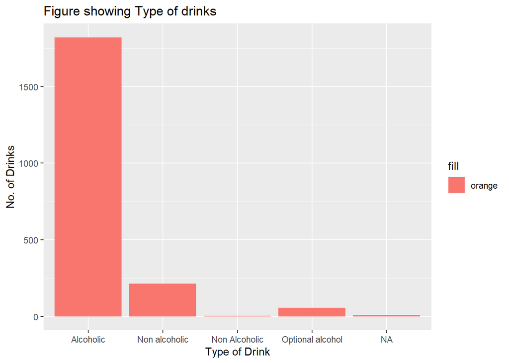

```r
cocktails %>%
  count(alcoholic) %>%
  ggplot(aes(alcoholic, n,  fill= "orange"))+
  geom_col()+
  labs(x = "Type of Drink", y = "No. of Drinks", title = "Figure showing Type of drinks")
```

This graph shows that along with alcoholic beverages, we have options for non-alcoholic beverages and few drinks with an option to have it with alcohol or without alcohol.

#### Ingredients

For serving this gigantic amount of drinks, we definitely have to look for the ingredients for all the drinks we need to serve. It would not be beneficial to serve those drinks that have numerous ingredients but are quite the least preferred choice of customers. Apart from it, after making a request for a drink, all a customer wants is that he is served as quick as possible. So it is crucial for us to know number of ingredients required in different cocktails.

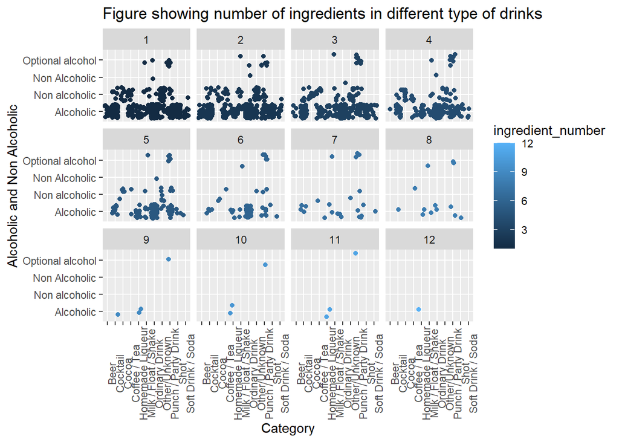

```r
cocktails %>%
  filter(!alcoholic == "NA") %>%
  ggplot(aes( category,alcoholic,color=ingredient_number)) +
  geom_jitter() +
  facet_wrap(~ ingredient_number) +
  theme(axis.text.x = element_text(angle = 90)) +
  labs(x = "Category", y = "Alcoholic and Non Alcoholic", title = "Figure showing number of ingredients in different type of drinks")
```

Keeping the main target on our mind, we further would like to enhance the customer service by serving them quickly which would indirectly lead to customer satisfaction and leading to more visitors.

### *How to attract more consumers?*

### **1. Presenting well**

Just providing a cocktail is not enough. We have to make a cocktail presentable. Cocktails have their own vibe and their own glasses! We would like our staff to know what glass should they use to serve a particular cocktail. So we design a model which help us identify the glass type based on the cocktail details.

#### Data Modelling: 1

Split the data set

```r
cocktails_split <- initial_split(cocktails)

cocktails_train <- training(cocktails_split)

cocktails_test <- testing(cocktails_split)
```

Recipe

```r
cocktails_recipe <- recipe(glass ~ alcoholic + category + ingredient_number, data=cocktails_train)

summary(cocktails_recipe)
```

```
## # A tibble: 4 x 4
##   variable          type    role      source
##   <chr>             <chr>   <chr>     <chr>
## 1 alcoholic         nominal predictor original
## 2 category          nominal predictor original
## 3 ingredient_number numeric predictor original
## 4 glass             nominal outcome   original
```

Remove outliers

```r
cocktails_recipe <- cocktails_recipe%>%
  step_center(all_numeric(), -all_outcomes())%>%
  step_scale(all_numeric(), -all_outcomes())%>%
  step_corr(all_numeric())
```

Preparation

```r
cocktails_prep <- prep(cocktails_recipe, training = cocktails_train)
```

Bake

```r
cocktails_bake <- bake(cocktails_prep, cocktails_train)
```

#### Classification Model

Now, we will use the cocktails_bake data set with random forest. We would like to know the glass to be used to serve the cocktails. Hence the output here is “glass” and as it is character variable, we will use random forest. We can also convert all the variables to factor in the data set. Here, inputs will be ‘alcoholic’ and ‘category’.

```r
#install.packages(randomForest)
library(randomForest)
cocktails_bake <- cocktails_bake %>%
  mutate_if(is.character, factor)


cocktails_bake <- droplevels(cocktails_bake)

rf_glass1 <- randomForest(glass ~ alcoholic + category, data = cocktails_bake, na.action=na.omit)

print (rf_glass1)
```

```
##
## Call:
##  randomForest(formula = glass ~ alcoholic + category, data = cocktails_bake,      na.action = na.omit)
##                Type of random forest: classification
##                      Number of trees: 500
## No. of variables tried at each split: 1
##
##         OOB estimate of  error rate: 64.29%
## Confusion matrix:
##                          Beer Glass Beer mug Beer pilsner Brandy snifter
## Beer Glass                        0        0            0              0
## Beer mug                          0        0            0              0
## Beer pilsner                      0        0            0              0
## Brandy snifter                    0        0            0              0
## Champagne flute                   0        0            0              0
## Champagne Flute                   0        0            0              0
## Cocktail glass                    0        0            0              0
## Cocktail Glass                    0        0            0              0
## Coffee mug                        0        0            0              0
## Coffee Mug                        0        0            0              0
## Collins glass                     0        0            0              0
## Collins Glass                     0        0            0              0
## Copper Mug                        0        0            0              0
## Cordial glass                     0        0            0              0
## Highball glass                    0        0            0              0
## Highball Glass                    0        0            0              0
## Hurricane glass                   0        0            0              0
## Irish coffee cup                  0        0            0              0
## Jar                               0        0            0              0
## Margarita glass                   0        0            0              0
## Margarita/Coupette glass          0        0            0              0
## Martini Glass                     0        0            0              0
## Mason jar                         0        0            0              0
## Old-fashioned glass               0        0            0              0
## Old-Fashioned glass               0        0            0              0
## Parfait glass                     0        0            0              0
## Pint glass                        0        0            0              0
## Pitcher                           0        0            0              0
## Pousse cafe glass                 0        0            0              0
## Punch bowl                        0        0            0              0
```

[output cut: 361 more lines]

```
## Martini Glass             1.00000000
## Mason jar                 1.00000000
## Old-fashioned glass       1.00000000
## Old-Fashioned glass       1.00000000
## Parfait glass             0.00000000
## Pint glass                1.00000000
## Pitcher                   1.00000000
## Pousse cafe glass         1.00000000
## Punch bowl                0.63636364
## Punch Bowl                1.00000000
## Shot glass                0.00000000
## Shot Glass                1.00000000
## Whiskey sour glass        1.00000000
## White wine glass          1.00000000
## Wine Glass                0.71428571
```

We can see that the estimated error rate of this model is quite high (almost above 60%). This shows that this model does not provide accurate result. But we can definitely try new combination of inputs that might result to lower error rate. Now trying to use all three inputs- alcoholic, category and ingredient_number.

```r
rf_glass2 <- randomForest(glass ~ . , data = cocktails_bake, na.action=na.omit)

print (rf_glass2)
```

```
##
## Call:
##  randomForest(formula = glass ~ ., data = cocktails_bake, na.action = na.omit)
##                Type of random forest: classification
##                      Number of trees: 500
## No. of variables tried at each split: 1
##
##         OOB estimate of  error rate: 64.29%
## Confusion matrix:
##                          Beer Glass Beer mug Beer pilsner Brandy snifter
## Beer Glass                        0        0            0              0
## Beer mug                          0        0            0              0
## Beer pilsner                      0        0            0              0
## Brandy snifter                    0        0            0              0
## Champagne flute                   0        0            0              0
## Champagne Flute                   0        0            0              0
## Cocktail glass                    0        0            0              0
## Cocktail Glass                    0        0            0              0
## Coffee mug                        0        0            0              0
## Coffee Mug                        0        0            0              0
## Collins glass                     0        0            0              0
## Collins Glass                     0        0            0              0
## Copper Mug                        0        0            0              0
## Cordial glass                     0        0            0              0
## Highball glass                    0        0            0              0
## Highball Glass                    0        0            0              0
## Hurricane glass                   0        0            0              0
## Irish coffee cup                  0        0            0              0
## Jar                               0        0            0              0
## Margarita glass                   0        0            0              0
## Margarita/Coupette glass          0        0            0              0
## Martini Glass                     0        0            0              0
## Mason jar                         0        0            0              0
## Old-fashioned glass               0        0            0              0
## Old-Fashioned glass               0        0            0              0
## Parfait glass                     0        0            0              0
## Pint glass                        0        0            0              0
## Pitcher                           0        0            0              0
## Pousse cafe glass                 0        0            0              0
## Punch bowl                        0        0            0              0
```

[output cut: 361 more lines]

```
## Martini Glass              1.0000000
## Mason jar                  1.0000000
## Old-fashioned glass        0.8658537
## Old-Fashioned glass        1.0000000
## Parfait glass              0.1250000
## Pint glass                 1.0000000
## Pitcher                    1.0000000
## Pousse cafe glass          1.0000000
## Punch bowl                 0.9318182
## Punch Bowl                 1.0000000
## Shot glass                 0.0000000
## Shot Glass                 1.0000000
## Whiskey sour glass         1.0000000
## White wine glass           1.0000000
## Wine Glass                 0.7142857
```

Even this model shows a higher error rate. Therefore, we can say that both the models here cannot predict the result accurately.

### **2. Helping them choose their drink.**

Many people love to explore different bars and restaurants but one of the common questions they have is ‘What should they order?’ It is not necessary that everyone has a great knowledge about cocktails. So majority of the crowd just order drinks they have already tried it or something that is similar to what they have tried.

To enhance their experience and giving them oppurtunity to try new drinks, we are trying to make a model which can give the ‘drink id’ based on the consumer’s selection of type of drink and ingredients. It is easier for the people to share what ingredients they like or would like to try and we would be able to serve them as per their needs. If we do not have a cocktail with all the ingredients the customer is requesting we could always make a new one!

#### Data Modelling: 2

Pre-processing

```r
cocktails_recipe2 <- recipe(id_drink ~ alcoholic + category + ingredient, data=cocktails_train)

summary(cocktails_recipe2)
```

```
## # A tibble: 4 x 4
##   variable   type    role      source
##   <chr>      <chr>   <chr>     <chr>
## 1 alcoholic  nominal predictor original
## 2 category   nominal predictor original
## 3 ingredient nominal predictor original
## 4 id_drink   numeric outcome   original
```

Remove outliers

```r
cocktails_recipe2 <- cocktails_recipe2%>%
  step_center(all_numeric(), -all_outcomes())%>%
  step_scale(all_numeric(), -all_outcomes())%>%
  step_corr(all_numeric())
```

Preparation

```r
cocktails_prep2 <- prep(cocktails_recipe2, training = cocktails_train)
```

Bake

```r
cocktails_bake2 <- bake(cocktails_prep2, cocktails_train)
```

#### Linear modelling

With help of dataset cocktails_bake2, we will try to predict ‘drink id’ only with 2 input variables ‘alcoholic’ and ‘ingredients’. Customer can provide their choice of ingredient and if their preferred type and we will serve them a drink accordingly. As drink id is a numeric variable we will use linear modelling.

```r
lm_drink1 <- lm(id_drink ~ alcoholic + ingredient, data = cocktails_bake2, na.action=na.omit)

summary(lm_drink1)
```

```
##
## Call:
## lm(formula = id_drink ~ alcoholic + ingredient, data = cocktails_bake2,
##     na.action = na.omit)
##
## Residuals:
##     Min      1Q  Median      3Q     Max
## -3935.6 -1016.7   -33.6   723.6  5220.6
##
## Coefficients:
##                                      Estimate Std. Error t value Pr(>|t|)
## (Intercept)                          14933.50     567.63  26.308  < 2e-16 ***
## alcoholicNon alcoholic                -905.59     202.70  -4.468 8.61e-06 ***
## alcoholicNon Alcoholic                4130.45    1067.32   3.870 0.000114 ***
## alcoholicOptional alcohol               51.71     315.35   0.164 0.869773
## ingredient7-Up                         105.30     983.17   0.107 0.914724
## ingredientAbsolut Citron              -265.83     926.94  -0.287 0.774322
## ingredientAbsolut Kurant              -196.50    1181.62  -0.166 0.867949
## ingredientAbsolut Peppar             -1863.50    1882.62  -0.990 0.322439
## ingredientAbsolut Vodka                134.83    1181.62   0.114 0.909169
## ingredientAdvocaat                   -1133.50    1390.41  -0.815 0.415094
## ingredientAgave Syrup                 2241.50    1882.62   1.191 0.234022
## ingredientAle                        -1651.50    1882.62  -0.877 0.380525
## ingredientAlmond                     -2139.50    1882.62  -1.136 0.255984
## ingredientAlmond flavoring           -1639.70    1394.09  -1.176 0.239745
## ingredientAmaretto                    -769.62     671.63  -1.146 0.252053
## ingredientAñejo rum                  -3814.50    1882.62  -2.026 0.042957 *
## ingredientAngelica root              -2079.50    1882.62  -1.105 0.269552
## ingredientAngostura bitters             80.25    1061.94   0.076 0.939774
## ingredientAngostura Bitters           2269.00    1390.41   1.632 0.102950
## ingredientAnis                       -1837.00    1390.41  -1.321 0.186674
## ingredientAnise                      -2141.50    1390.41  -1.540 0.123762
## ingredientAnisette                   -2712.50    1390.41  -1.951 0.051293 .
## ingredientAperol                     -2227.50    1882.62  -1.183 0.236955
## ingredientApple                      -1711.64    1183.55  -1.446 0.148371
## ingredientApple brandy               -3645.50    1390.41  -2.622 0.008849 **
## ingredientApple cider                -2121.21    1908.85  -1.111 0.266670
## ingredientApple juice                 -435.20     932.46  -0.467 0.640777
## ingredientApple schnapps             -1250.50    1882.62  -0.664 0.506661
## ingredientApplejack                  -3909.50    1390.41  -2.812 0.005003 **
```

[output cut: 267 more lines]

```
## ingredientWhite rum                  -1727.50    1882.62  -0.918 0.359000
## ingredientWhite Rum                   2285.50    1882.62   1.214 0.224974
## ingredientWild Turkey                  213.50    1390.41   0.154 0.877987
## ingredientWine                       -2915.70     983.17  -2.966 0.003077 **
## ingredientYellow Chartreuse          -3644.00    1390.41  -2.621 0.008877 **
## ingredientYoghurt                    -1353.24    1198.88  -1.129 0.259215
## ingredientYukon Jack                   244.50    1882.62   0.130 0.896688
## ingredientZima                         867.50    1882.62   0.461 0.645025
## ---
## Signif. codes:  0 '***' 0.001 '**' 0.01 '*' 0.05 '.' 0.1 ' ' 1
##
## Residual standard error: 1795 on 1267 degrees of freedom
##   (7 observations deleted due to missingness)
## Multiple R-squared:  0.4161, Adjusted R-squared:  0.2765
## F-statistic:  2.98 on 303 and 1267 DF,  p-value: < 2.2e-16
```

We can also use all the input variables alcoholic, category and ingredients to predict the output drink id.

```r
lm_drink2 <- lm(id_drink ~ . , data = cocktails_bake2, na.action=na.omit)

summary(lm_drink2)
```

```
##
## Call:
## lm(formula = id_drink ~ ., data = cocktails_bake2, na.action = na.omit)
##
## Residuals:
##     Min      1Q  Median      3Q     Max
## -3481.9  -886.2  -114.2   585.5  5422.8
##
## Coefficients:
##                                       Estimate Std. Error t value Pr(>|t|)
## (Intercept)                          14467.464    847.415  17.072  < 2e-16 ***
## alcoholicNon alcoholic               -2142.617    216.564  -9.894  < 2e-16 ***
## alcoholicNon Alcoholic                4669.864    953.009   4.900 1.08e-06 ***
## alcoholicOptional alcohol             -844.730    314.447  -2.686 0.007318 **
## categoryCocktail                      1784.820    686.178   2.601 0.009402 **
## categoryCocoa                         1599.361    802.733   1.992 0.046544 *
## categoryCoffee / Tea                  1133.328    729.032   1.555 0.120301
## categoryHomemade Liqueur              -234.181    745.372  -0.314 0.753437
## categoryMilk / Float / Shake          1566.588    732.226   2.139 0.032588 *
## categoryOrdinary Drink                -573.863    675.136  -0.850 0.395489
## categoryOther/Unknown                 1857.222    714.012   2.601 0.009401 **
## categoryPunch / Party Drink           1030.053    696.496   1.479 0.139415
## categoryShot                           554.679    698.488   0.794 0.427279
## categorySoft Drink / Soda             1354.592    723.968   1.871 0.061568 .
## ingredient7-Up                         213.016    881.273   0.242 0.809042
## ingredientAbsolut Citron             -1403.728    836.011  -1.679 0.093385 .
## ingredientAbsolut Kurant              -478.026   1059.756  -0.451 0.652015
## ingredientAbsolut Peppar             -1952.143   1682.439  -1.160 0.246145
## ingredientAbsolut Vodka                388.504   1059.187   0.367 0.713834
## ingredientAdvocaat                    -657.872   1240.639  -0.530 0.596019
## ingredientAgave Syrup                 3281.398   1681.497   1.951 0.051222 .
## ingredientAle                        -1185.464   1810.101  -0.655 0.512641
## ingredientAlmond                     -1439.284   1710.289  -0.842 0.400203
## ingredientAlmond flavoring            -953.093   1260.749  -0.756 0.449807
## ingredientAmaretto                    -653.917    602.558  -1.085 0.278026
## ingredientAñejo rum                  -2774.602   1681.497  -1.650 0.099177 .
## ingredientAngelica root              -1379.284   1710.289  -0.806 0.420129
## ingredientAngostura bitters           -648.864    957.092  -0.678 0.497926
## ingredientAngostura Bitters            950.216   1250.571   0.760 0.447501
## ingredientAnis                       -1361.372   1240.639  -1.097 0.272714
```

[output cut: 276 more lines]

```
## ingredientWhite rum                   -687.602   1681.497  -0.409 0.682666
## ingredientWhite Rum                    966.716   1686.151   0.573 0.566526
## ingredientWild Turkey                  124.857   1245.562   0.100 0.920169
## ingredientWine                       -2196.585    882.640  -2.489 0.012951 *
## ingredientYellow Chartreuse          -2604.102   1244.289  -2.093 0.036563 *
## ingredientYoghurt                    -1410.525   1077.977  -1.308 0.190945
## ingredientYukon Jack                   155.857   1682.439   0.093 0.926206
## ingredientZima                         303.482   1688.076   0.180 0.857354
## ---
## Signif. codes:  0 '***' 0.001 '**' 0.01 '*' 0.05 '.' 0.1 ' ' 1
##
## Residual standard error: 1599 on 1257 degrees of freedom
##   (7 observations deleted due to missingness)
## Multiple R-squared:   0.54,  Adjusted R-squared:  0.4255
## F-statistic: 4.715 on 313 and 1257 DF,  p-value: < 2.2e-16
```

With the help of this model we can help the confused consumers to choose their drink based on the ingredients they like. This will help them explore new combination of ingredients and encourage them to openly try new cocktails every time they visit as they are already familiar with the ingredients.

### Conclusion

These strategies can help in expanding the business to a new level. Profit maximization along with customer satisfaction is the key to success. And we cannot deny the fact that exploring different cocktails is an adventure in its own!

*Cheers!*